# R Notebook

### Instructions: Run Custom Style from R_Style_Templates

### Create the dataframe

Note to self: only need time first

### Explore the data

#Very basic - more detail in R_Explore_Data: learn how to view the averages of multiple columns at once, for ex

```r
mean(dat$total_bill)
```

```
[1] 10.79143
```

### Create Basic Bar Chart

Reference: http://www.cookbook-r.com/Graphs/Bar_and_line_graphs_(ggplot2)/ To make this a tutorial, do a very basic chart to start, then add layers so people can view the changes Have two tracks: 1) STYLE: show what the chart looks like with default theme, then peel away the layers of NVA ink to get to Tufte, customize colors (can be a teaser - add one element and you can make the chart look like THIS or THIS), customize legend, etc 2) CONTENT: add fill based on value, change fill to be based on category, make horizontal, make stacked bar

### Create Bar Chart Outline

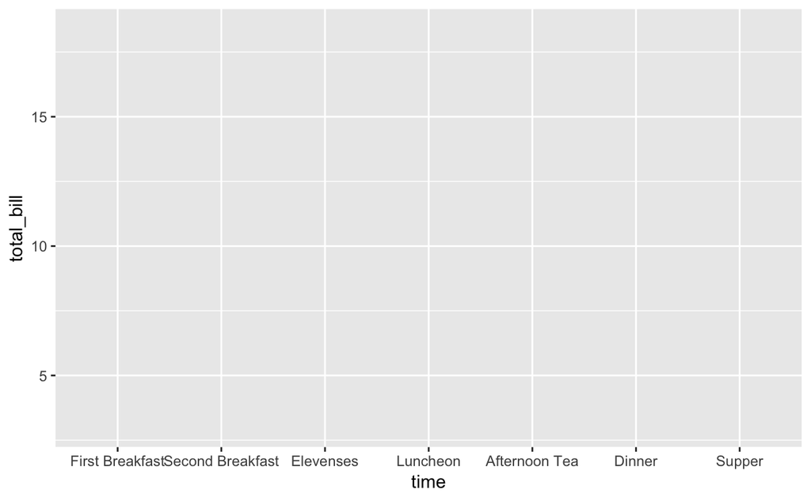

# this is bare minimum

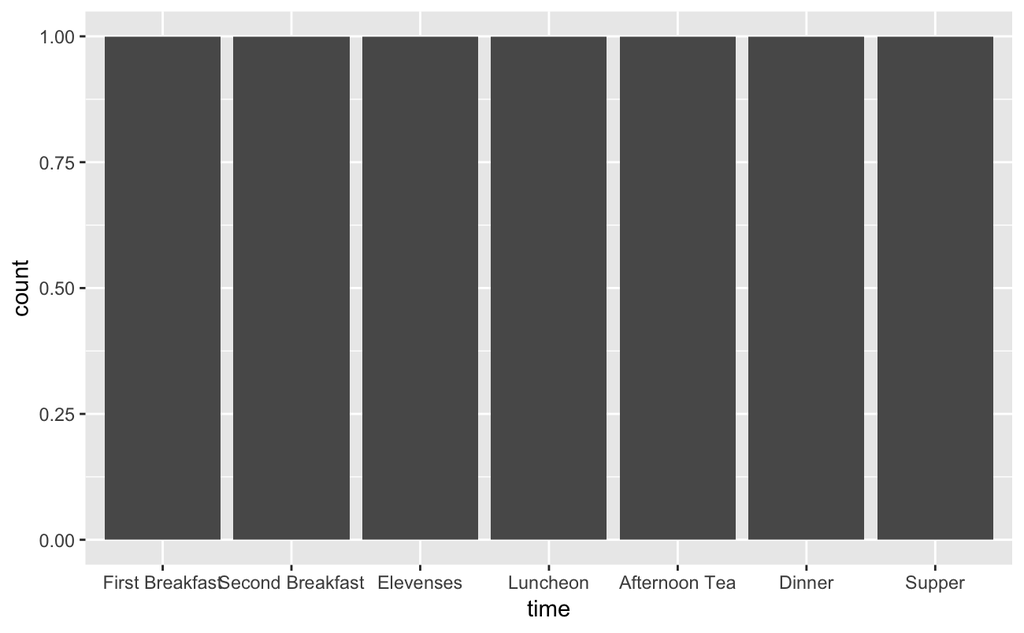

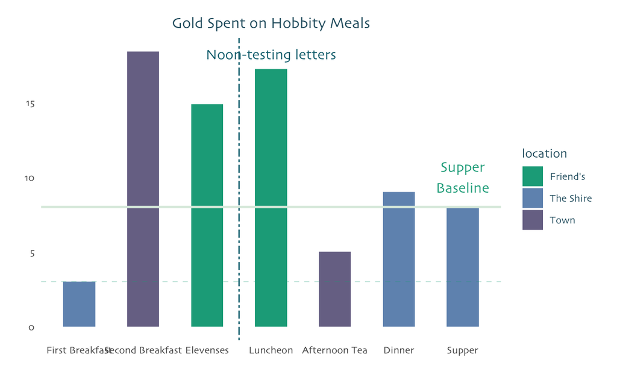

### Make the Bar Chart Horizontal

Reference: https://ggplot2.tidyverse.org/reference/geom_bar.html#computed-variables #Note: this does not modify bchart itself

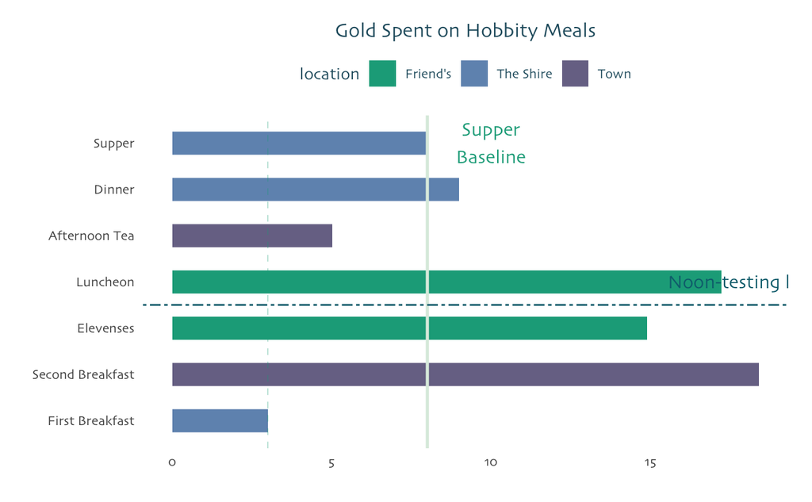

### Move the Legend in the horizontal bar chart to a coordinate within the graph

Reference: http://www.sthda.com/english/wiki/ggplot2-legend-easy-steps-to-change-the-position-and-the-appearance-of-a-graph-legend-in-r-software

```r
bchart +
 coord_flip() +
 theme(legend.position = c(0.9, 0.8))
```

[output not shown]

```r
dat_csv3
```

```
    personid demo_sex state turnout_score support_score ev_score vbm_score gotv_score voted_2018
1          1     Male    IN        0.7164        0.3446   0.6222    0.5261     0.1031       true
2          2   Female    NJ        0.1303        0.4049   0.1376    0.0939     0.7351      false
3          3     Male    NV        0.8775        0.8984   0.3620    0.6974     0.5841      false
4          4   Female    VA        0.8618        0.1920   0.7894    0.5906     0.9322       true
5          5   Female    WA        0.2244        0.2307   0.9972    0.4839     0.0294       true
6          6     Male    CA        0.0878        0.2405   0.3252    0.6333     0.7293      false
7          7   Female    NE        0.4311        0.2568   0.6235    0.5043     0.4199       true
8          8     Male    PA        0.2028        0.2848   0.6889    0.2501     0.9570       true
9          9     Male    AL        0.2892        0.7187   0.3510    0.1764     0.9851      false
10        10     Male    FL        0.0676        0.2228   0.0310    0.1236     0.6804      false
11        11     Male    IN        0.5091        0.9243   0.2721    0.6480     0.2583       true
12        12   Female    WA        0.4808        0.5221   0.3479    0.9385     0.9643      false
13        13   Female    NE        0.8352        0.8795   0.0347    0.1647     0.9333       true
14        14   Female    FL        0.2860        0.6347   0.0671    0.2607     0.0659       true
```

[output cut: 188 more lines]

### Make a stacked bar chart: make the fill a categorial variable that is NOT the x-axis

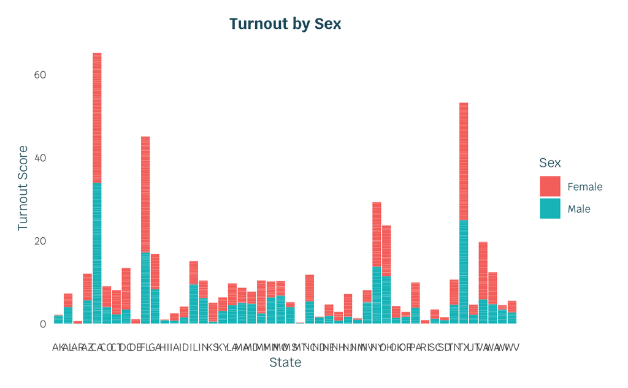

### Make a stacked bar chart that stretches to 100% always

To do: fix these labels - remove the rectangle, coordinate the colors

```r
dat_pct <- data.frame(ethnicity = factor(c("White","AfAm","AAPI","Hisp")),
  pct_dist = c(.5,.2,.1,.2))

ggplot(data=dat_pct, aes(x=1, y=pct_dist, fill=pct_dist))+
  geom_bar(stat="identity") +theme_ss+
  geom_label(aes(label=ethnicity), size=5)
  # geom_text(mapping = NULL, data = NULL, stat = "identity", position = "identity",inherit.aes = TRUE)

# create chart of 2-way
dat_2way <- data.frame(
  demo = factor(c("State","State","State","State","State","Sex","Sex"), levels=c("Sex","State")),
  level = factor(c("NV","AZ","NY","HI","WV","Female","Male")),
  Dem = c(.531,.512,.723,.825,.32,.62,.43))

# add another level that's Rep = 1-dat_way$Dem
dat_2way$Rep <- 1 - dat_2way$Dem
head(dat_2way)

# to save storage space, how to manufacture this (1-Dem) calculation in a stacked bar chart?

ggplot(data=dat_2way, aes(x=demo,y=Dem, fill=Dem))+
  geom_bar(stat="identity")+theme_ss+
  geom_label(aes(label=level))+
  scale_color_gradient2(low = bluelabs_colors[1], high = bluelabs_colors[5], midpoint = .5, mid = 'grey')
```

[output not shown]

## Make a bar chart where each bar is colored differently

fill = time (the x-axis variable)

```r
ggplot(data=dat, aes(x=time, y=total_bill, fill=time)) +
    geom_bar(stat="identity") + theme_ss
```

[output not shown]

### Make a scatterplot

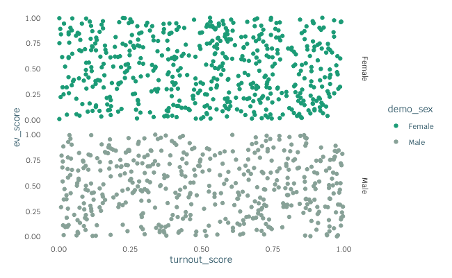

### Create animated chart

Reference: https://github.com/thomasp85/gganimate https://www.ggplot2-exts.org/gganimate.html

```r
ggplot(subset(dat_csv3, state %in% c("FL","NV","AZ")), aes(x=turnout_score, y=ev_score, fill=demo_sex))+
  geom_point(aes(color=demo_sex)) + theme_ss+
  #customize colors
  scale_color_manual(values=c("#14A989","#2F4858"))+
  #labels
  labs(title = 'Early Vote Score vs Turnout Score by Gender',
       y = "Early Vote Score",
       x = "Turnout Score")+
  #format axis labels
  scale_x_continuous(labels = scales::percent_format(accuracy=1))+
  scale_y_continuous(labels = scales::percent_format(accuracy=1))+
  #split by sex
  facet_wrap(~demo_sex)+
  theme(legend.position="none")+
  #gganimate
  transition_states(states = state,transition_length = 2)+
  ease_aes('linear')
```

[output not shown]

[output not shown]

[output cut: 46 more lines]

[output not shown]

### add labels that repel each other(don’t overlap) HAven’t test yet

Reference: http://r-statistics.co/Complete-Ggplot2-Tutorial-Part2-Customizing-Theme-With-R-Code.html#3.%20Adding%20Text,%20Label%20and%20Annotation

```r
# Plot text and label that REPELS eachother (using ggrepel pkg) ------------
library(ggrepel)
gg + geom_text_repel(aes(label=large_county), size=2, data=midwest_sub) + labs(subtitle="With ggrepel::geom_text_repel") + theme(legend.position = "None")   # text

gg + geom_label_repel(aes(label=large_county), size=2, data=midwest_sub) + labs(subtitle="With ggrepel::geom_label_repel") + theme(legend.position = "None")   # label
```

## Create stacked area chart

reference for basic area chart: https://www.oreilly.com/library/view/r-graphics-cookbook/9781449363086/ch04.html reference for stacked bar chart: https://www.r-graph-gallery.com/136-stacked-area-chart/ raw data: https://docs.google.com/spreadsheets/d/1_QFlhKbwKzX9B1ubKHL72A8qg2yZzNXAffoeqyILwHE/edit#gid=429744481

###first create the base table checking what format the data should be in (ie mult columns adding up to a total or multiple rows)

```r
data
```

```
   Sector Year    Value
1     S01 1950 29.46283
2     S02 1950 34.72876
3     S03 1950 45.09326
4     S04 1950 69.01657
5     S05 1950 49.22797
6     S06 1950 82.31357
7     S07 1950 44.71119
8     S01 1960 84.99715
9     S02 1960 52.57713
10    S03 1960 18.40441
11    S04 1960 33.68772
12    S05 1960 95.22229
13    S06 1960 25.90978
14    S07 1960 66.19618
```

[output cut: 35 more lines]

```r
df_money
```

```
  Year total_VG
1 2015   236745
2 2016   415765
3 2017   585809
4 2018   586902
```

## Import vertical account data (dummy data) for stacked area chart

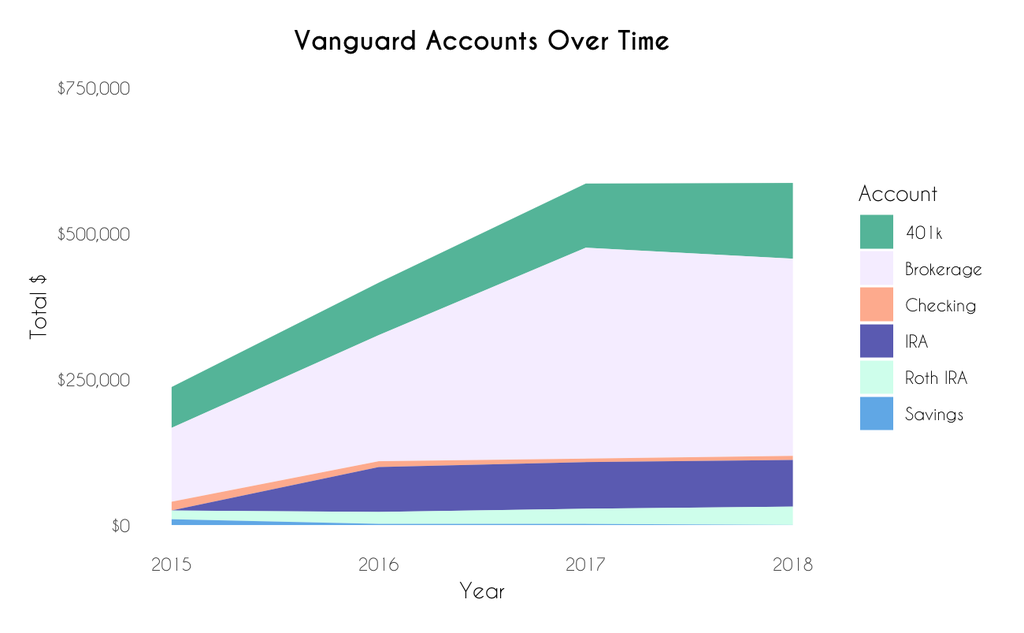

###split by category not account type

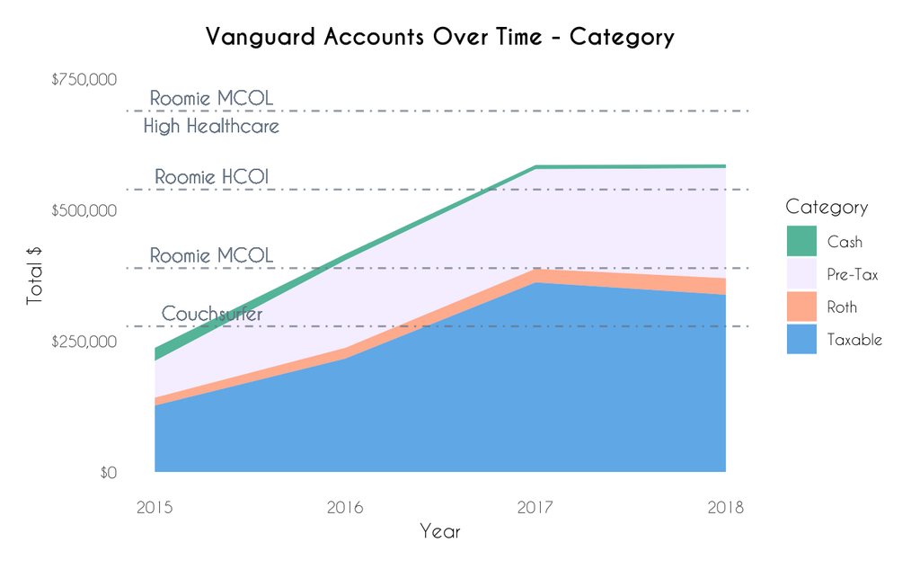

## create column charts w/ outlines/dark fill/light fill

things to practice: set the thickness of an outline based on a category: https://stackoverflow.com/questions/45153939/r-is-it-possible-to-render-more-precise-outline-weights-in-ggplot2 change the alpha based on a category change the fill/label/width/color

```r
ggplot()+
  geom_col(data=full_toplines_pvi_new, aes(x = reorder(seat,pvi), y = 100*value,
                                            fill = winner,
                                           # alpha = 5,
                                            # show.legend = FALSE,
                                            label = seat, width = .8),
           alpha = .8)+
  scale_fill_manual(values = c(bluelabs_colors[5], bluelabs_colors[5],bluelabs_colors[7], bluelabs_colors[7]),
                    name = '', guide = 'none')+
  geom_col(data=full_toplines_pvi_new, aes(x = reorder(seat, pvi), y = `2012_margin`*100,
                                  fill =  winner12,
                                  width = .6,
                                  color=NA),
           alpha = .5,)+
  geom_col(data=full_toplines_pvi_new, aes(x = reorder(seat, pvi), y = pvi*100,
                                           fill = NA,
                                           linetype = target_lab,
                                           #set the thickness of the outline on whether a state is a DSCC target
                                           #still need to manually set the thickness of the line below using scale_size_manual
                                           size = target_lab,
                                           color=party_lean))+
  scale_color_manual(values=c("Republican"=bluelabs_colors[7],
                              "Democratic"=bluelabs_colors[5]),
                     name = '', guide = 'none')+
  #make target states solid line, non-target states dotted
  scale_linetype_manual(values=c("dotted", "solid"))+
  #set the
  scale_size_manual(values = c(1.1, 1.3))+
  geom_text(size = 2, alpha = 1)+
  theme_bluelabs+
  theme(panel.grid.major = element_blank(),
        panel.grid.minor = element_blank(),
        axis.text.y = element_blank())+
  labs(y = 'Performance Relative to Partisanship & 2018 Dem Margin\n ',
       x = element_blank(),
       title = '2018 Democratic Candidate Margin Relative to 2012')+
  # scale_alpha_discrete(range = c(.3,1,.3,1), name = '')+
  geom_hline(yintercept = 0, linetype = 'dashed')+
  # don't show legend for democratic/republican PVI outline
  guides(fill = FALSE, alpha = FALSE, linetype = FALSE, size = FALSE)+
  ylim(-50,50)
```

[output not shown]

## create proportional area chart with %

reference: https://stackoverflow.com/questions/27134516/summarizing-by-subgroup-percentage-in-r

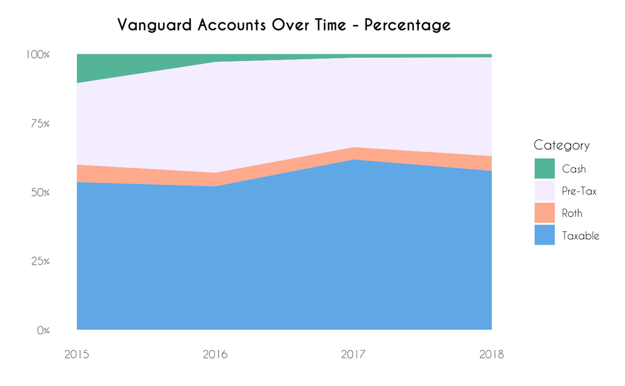